# Case Study 1

Chris Irwin

11/1/2016

# Analysis Instructions:

In order to start the analysis please start by opening r and set the working directory of your choice, using the setwd(“Your Location goes here”). It is very important that after setting your working directory you will need to create a folder called Analysis. Once the folder is created then download all the files located in the Analysis folder inside of GITHub. After starting the execution of the r script it is important to know that the script will create one new folder called Data. Inside of this folder will save the files after being downloaded from the URLs above. These files are created in case you wanted to take the analysis offline and not have to rely on re-downloading the file each time.

# Purpose:

This case study consists of 2 files, which are located on the internet and need to combined in order to answer the following questions.

1. Merge the data based on the country shortcode. How many of the IDs match?
2. Sort the data frame in ascending order by GDP (so United States is last). What is the 13th country in the resulting data frame?
3. What are the average GDP rankings for the “High income: OECD” and “High income: nonOECD” groups?
4. Plot the GDP for all of the countries. Use ggplot2 to color your plot by Income Group.
5. Cut the GDP ranking into 5 separate quantile groups. Make a table versus Income.Group. How many countries are Lower middle income but among the 38 nations with highest GDP?

In order to answer these questions we need to download the files from the internet using the following locations.

1. https://d396qusza40orc.cloudfront.net/getdata%2Fdata%2FGDP.csv
   1. This CSV file contains the GDP Data for 190 Countries
2. https://d396qusza40orc.cloudfront.net/getdata%2Fdata%2FEDSTATS_Country.csv  
   b. This csv file contains additional information for 234 countries

In order to complete the requested analysis we will need to download the listed files above using r and then merge the data sets using the country code, which is provided in both files.

### Set Working Directory

```r
setwd("/Users/cmirwin/Desktop/SMU Data Sets/Doing Data Science/Case Study 1")
```

### Create Folder Structures

```r
source("./Analysis/CreateFolderStructure.txt")
```

```
## Could not load tcltk.  Will use slower R code instead.
```

### Download GDP File from https://d396qusza40orc.cloudfront.net/getdata%2Fdata%2FGDP.csv

```r
source("./Analysis/DownloadGDPFile.txt")
```

```r
source("./Analysis/DownloadFedStatsFile.txt")
```

# Results

### Merging two data files into single data frame

```r
source("./Analysis/MergeData.txt")
```

## Question 1

#### Get the length of the matched datasets

```r
length(df.MergedData$CountryCode)
```

```
## [1] 189
```

## Question 2

#### Country with the 13th lowest GDP

```r
source("./Analysis/Question2.txt")

#Select the Short Name from the 13th GDP
GDP.Info[c("Short.Name")]
```

```
##             Short.Name
## 93 St. Kitts and Nevis
```

## Question 3

#### average GDP rankings for the “High income: OECD” and “High income:nonOECD” groups

```r
source("./Analysis/Question3.txt")

#Average Rank per Income Group
average.RankIncomeGroup
```

```
##           Income.Group  AvgRank
## 1    High income: OECD 32.96667
## 2 High income: nonOECD 91.91304
```

## Question 4

#### Execute and Run the Entire Graph

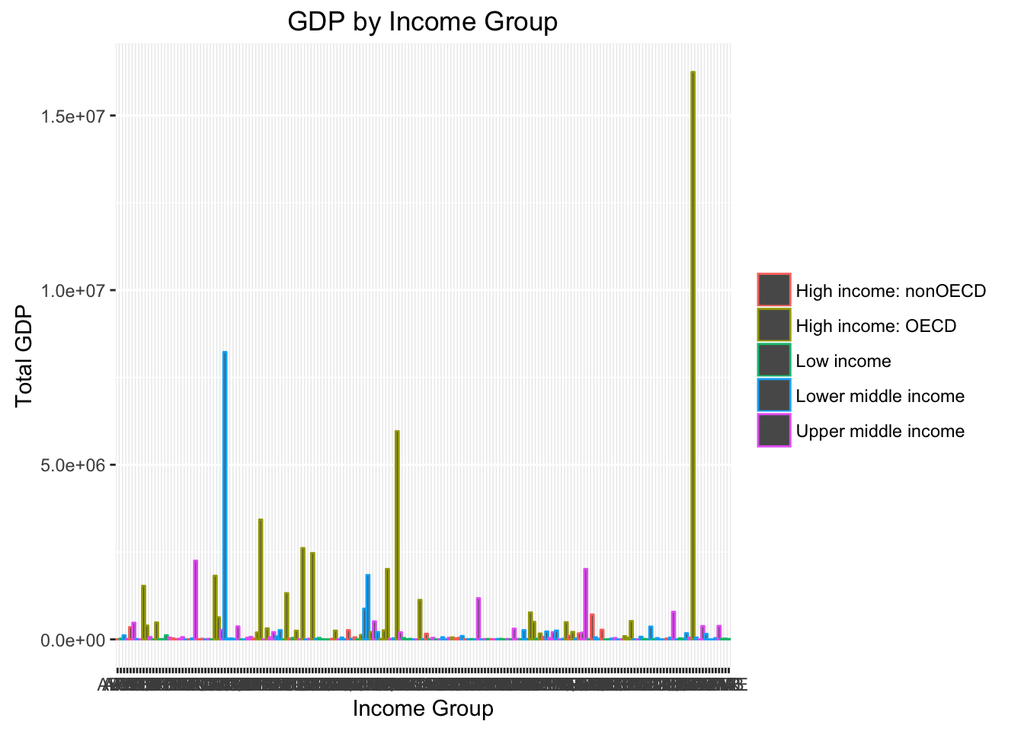

```r
#Execute Script to build Graph
source("./Analysis/Question4.txt")

#Create the Graph
plot + point + title + labels + legendInfo
```

## Question 5

#### Create table of Income Group Vs Quantiles

```r
source("./Analysis/Question5.txt")

Question5Table[,Select = (">80%")]
```

```
##                      High income: nonOECD    High income: OECD
##                    0                    4                   18
##           Low income  Lower middle income  Upper middle income
##                    0                    5                   11
```

# Conclusion: